# Optimización de Asignación de Ambulancias en Navarra

**Objetivo**

Asignar de forma eficiente sedes de ambulancias en Navarra utilizando GRASP, VNS y Tabu Search.

**Introducción**

Este informe presenta la aplicación de tres metaheurísticas para la asignación óptima de sedes y ambulancias en Navarra:

**GRASP (Greedy Randomized Adaptive Search Procedure)**

**VNS (Variable Neighborhood Search)**

**Tabu Search**

Cada técnica contribuye a mejorar progresivamente la solución inicial, respetando las restricciones del problema.

**¿Por qué GRASP como punto de partida?**

**Ventajas:**

Proporciona rápidamente soluciones factibles.

Su fase constructiva es voraz pero aleatorizada, permitiendo diversidad de soluciones.

Evita soluciones inviables desde el inicio (a diferencia de Simulated Annealing). Parámetros clave:

MAX_ITER = 400

Fase Constructiva:

Considera la población como criterio de prioridad.

α = 1: sin lista restringida, exploración completa.

Sesgo hacia municipios más poblados.

## Evolución del valor de mejora - GRASP

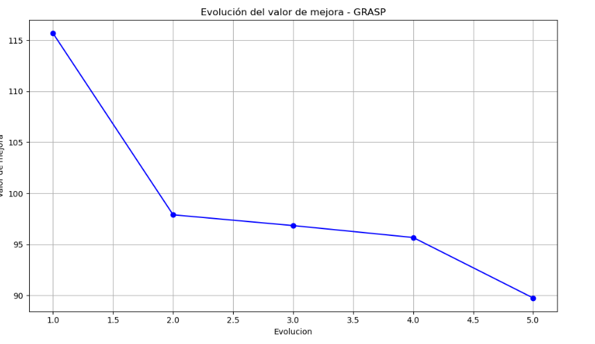

Objetivo: salir de óptimos locales explorando sistemáticamente vecindarios de tamaño creciente.

Mecanismo:

Alterna shaking (diversificación) con búsqueda local (intensificación).

Mejora sobre la solución inicial dada por GRASP.

Parámetros clave:

k_max = 5: máximo número de sedes a reemplazar.

max_iter = 50: iteraciones permitidas.

En cada iteración:

Se reemplazan k sedes activas aleatoriamente.

Si mejora, se reinicia k = 1. Si no, se incrementa hasta k_max.

[figure not shown]

[interactive chart not shown]